# New Approach

[figure not shown]

## Potential problem: Low-exposure targets are inherently more difficult

#### Solution: Can't say that certain targets were more difficult if only using a single target

## Potential problem: Total exposure measure previously collapsed data from early and late in game into one averaged data point

#### Solution: Now exposure is calculated on an individual trial basis

## Potential problem: Same trials occur less often than diff trials

#### Solution: If there is more variability in one of the line graphs (indicated by transparent colors), that doesn't undermine analysis. Can still look at difference between two regressions

- Also this would allow more trials to be included, as we no longer need to cutoff with players contributing same number of trials to same and different.

## Potential problem: Pro players would never be able to contribute to far right side of graph

#### Solution: Introduce cutoff where player needs to at least contribute to x number of exposures for inclusion in the data

## Potential problem: Far right of the graph comes from levels of harder difficulty (i.e., faster conveyor belt speeds)

#### Solution: Construct another plot where x-axis represents total trials from player at that point in the game

- This would more fully represent difference in priming benefit due to harder difficulty levels. Doing hierarchical analysis on difference between these two graphs with difference on the above graph would allow us to see if exposure explains priming benefit above and beyond level factors in the model.

# New Approach Results

So I did all the above and one problem is that you cannot simply regress out total trial number because it is inextricably linked with exposure number -- changing the x-axis would merely stretch out the line plot and not be useful. So instead I substituted out the total trial number for the trial onset of that target for each individual player. Trial onset can inform us about trial difficulty (i.e., later trial onset should lead to smaller priming benefits overall if difficulty really were responsible for our effects and not exposure). I also decided to construct graphs for more than just the pistol because why not.

This is the current pipeline:

```
For item number x
   For participant y
       Find all trials containing item x for participant y
           First trial with this item is recorded as trial_onset
              Find all trials passing exclusionary criteria
                  If participant has seen this item >= 100 times (else disregard player)
                      Log following variables
                          If "same" (each item_num has separate cell)
                              RT, exposure_num, par_num, trial_onset
                          If "diff" (saved as separate matrices from "same")
                              RT, exposure_num, par_num, trial_onset
```

Would have to repeat this all for accuracy instead of RT as well.

Note that number of trials included for "same" and "diff" conditions are no longer equal. This is because we are constructing a regression independently for both "diff" and "same" (and then looking at the difference in their slopes). I.e., we would predict that the regression slopes would be significantly different for "diff" and "same". Also note that no player can bias an exposure's RT more than any other player, as it is impossible to contribute more than one data point for the same exposure_number for any given target.

## Lots of Plots

Basically, for each item I constructed a linear regression for "same" and "different", along with their respective SEMs (calculated for each individual exposure number, taking into account itself and the previous and subsequent 5 exposures) to show variability. Then I subtracted the two regressions at each exposure number to result in a priming benefit across exposures for every item. It looks like this (SamePars refers to how many players contributed to "same" for that item. I excluded any targets that had less than 30 SamePars):

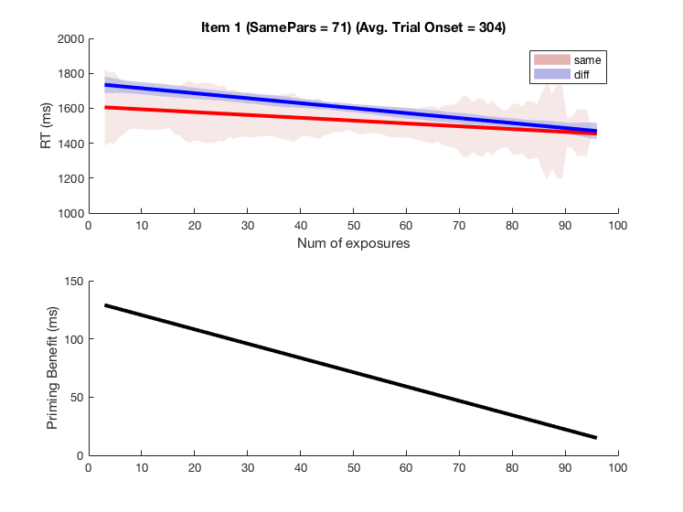

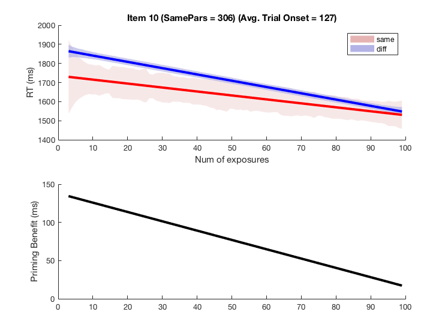

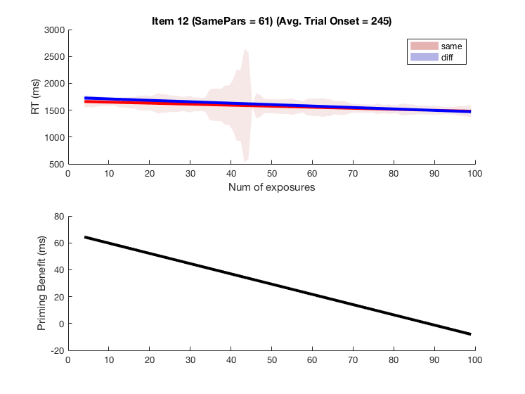

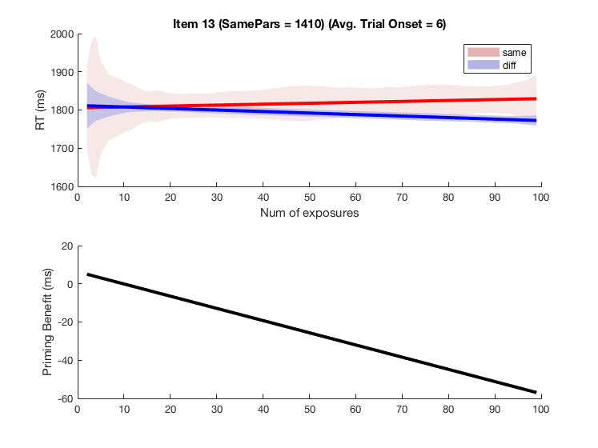

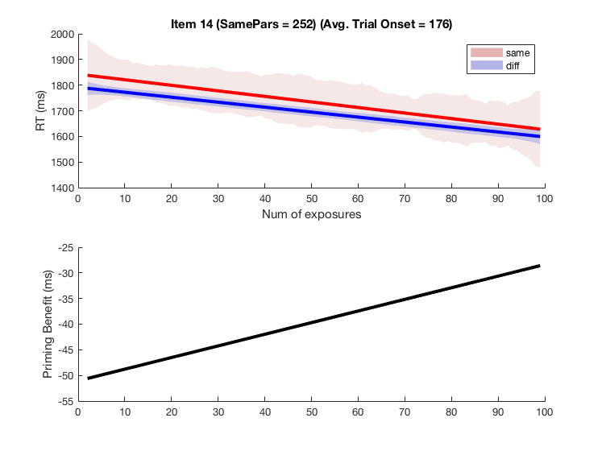

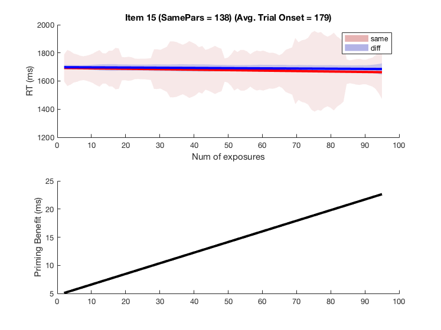

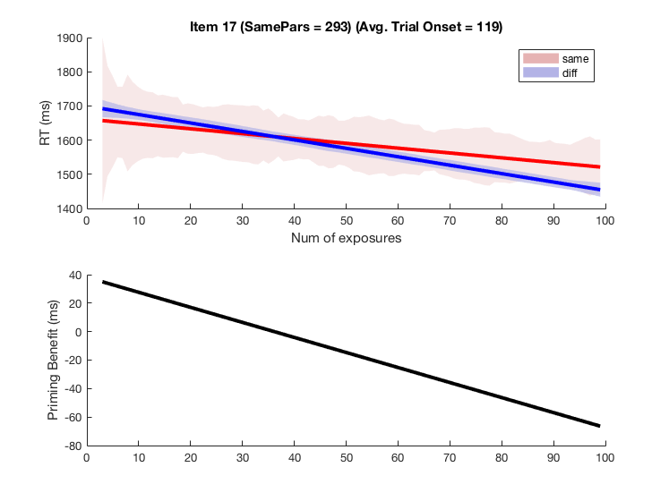

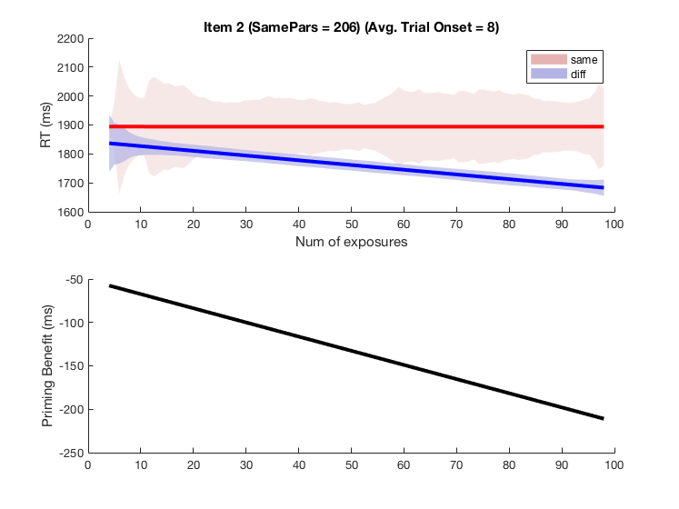

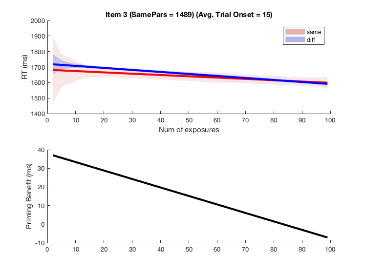

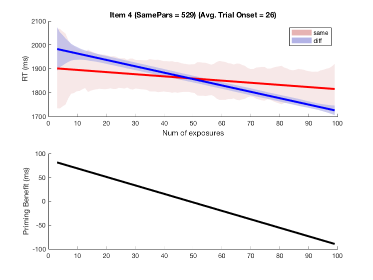

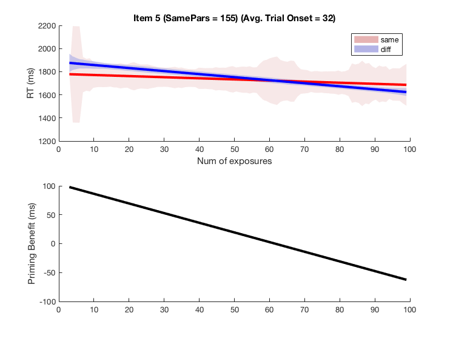

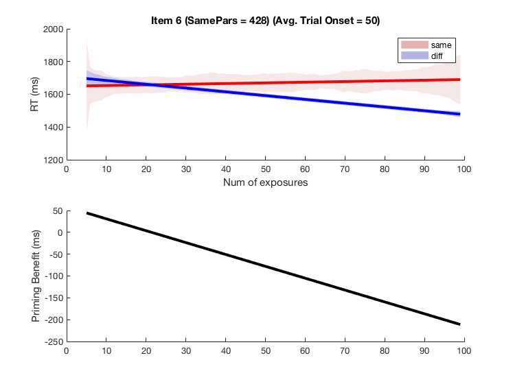

[3 more figures not shown]

```matlab
cd '/Users/scotti.5/OneDrive/Articles/__Mitroff/sandbox'
openfig('item 17.fig');
openfig('item 15.fig');
openfig('item 14.fig');
openfig('item 13.fig');
openfig('item 12.fig');
openfig('item 10.fig');
openfig('item 9.fig');
openfig('item 8.fig');
openfig('item 7.fig');
openfig('item 6.fig');
openfig('item 5.fig');
openfig('item 4.fig');
openfig('item 3.fig');
openfig('item 2.fig');
openfig('item 1.fig');
```

| **itemnum** | **slope_diff** | **avg. trial onset** | **median_split** |
| --- | --- | --- | --- |
| 1 | -1.23 | 304 | 14.67 |
| 2 | -1.63 | 8 | 47.74 |
| 3 | -0.46 | 15 | 19.77 |
| 4 | -1.78 | 26 | 73.4 |
| 5 | -1.67 | 32 | 149.79 |
| 6 | -2.72 | 50 | 88 |
| 7 | -0.45 | 47 | 16.19 |
| 8 | -0.01 | 109 | 119.47 |
| 9 | -0.06 | 102 | -4.69 |
| 10 | -1.22 | 127 | 60.7 |
| 12 | -0.76 | 245 | -36.63 |
| 13 | -0.64 | 6 | 25.48 |
| 14 | 0.23 | 176 | -32.61 |
| 15 | 0.19 | 179 | -32.65 |
| 17 | -1.06 | 119 | 58.75 |

Slope_diff refers to the slope of the priming benefit plot (negative slope meaning more priming benefit for earlier exposure).

Median_split involves taking the average priming benefit across exposures 1-50 and subtracting from that the average priming benefit across exposures 51-100, to get a rough estimate of effect size (in milliseconds, positive number means greater priming benefit for earlier exposure).

Now we need to figure out what to do with all of this... It seems like trial onset isn't really changing the sizes of these effects much, and 13/15 targets showed priming benefit decrease over time.

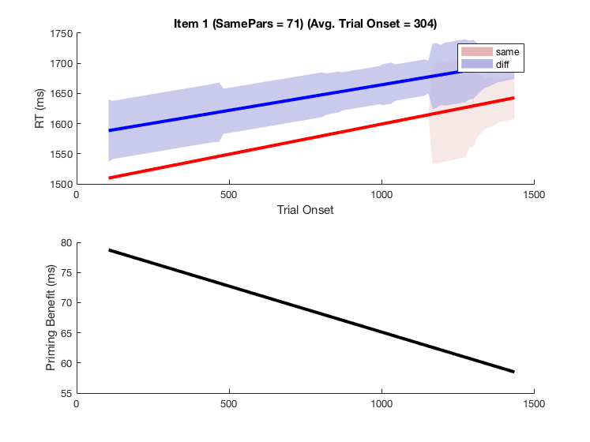

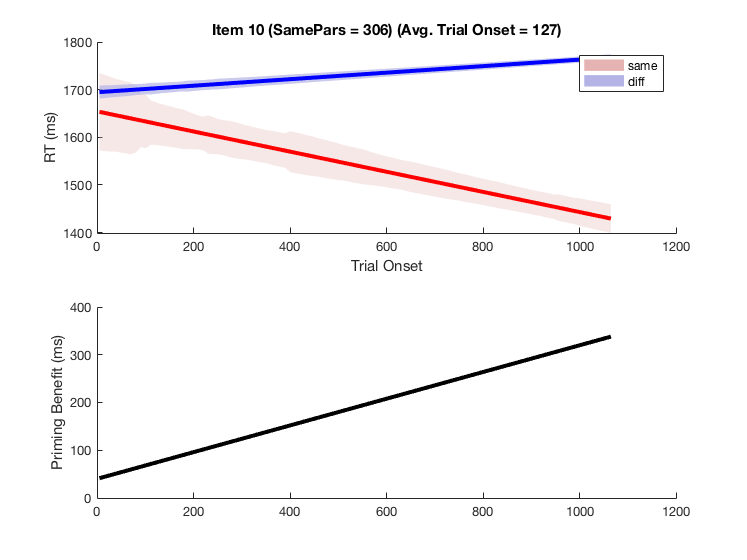

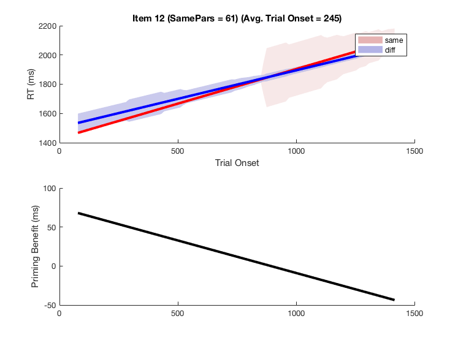

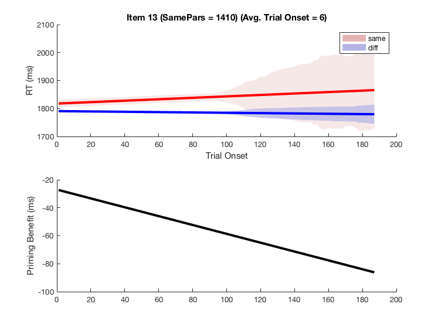

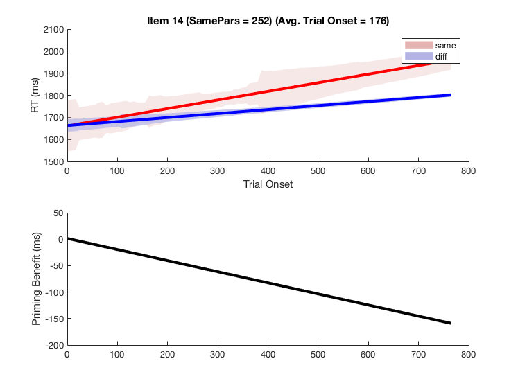

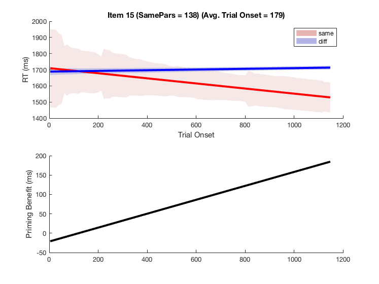

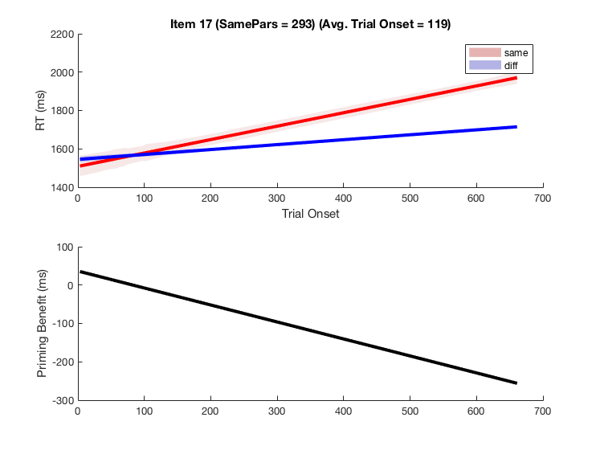

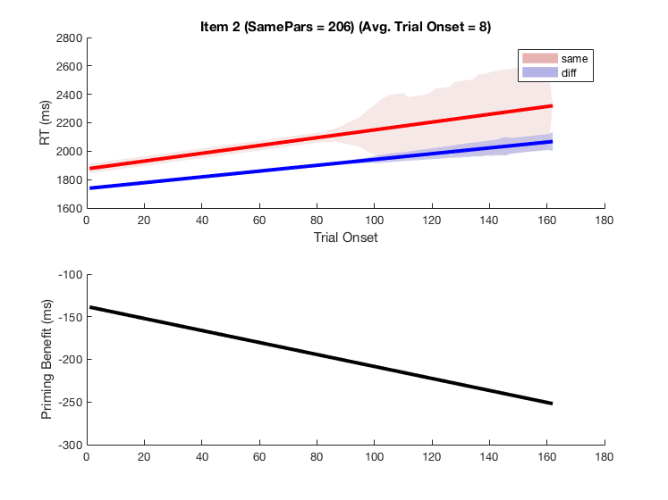

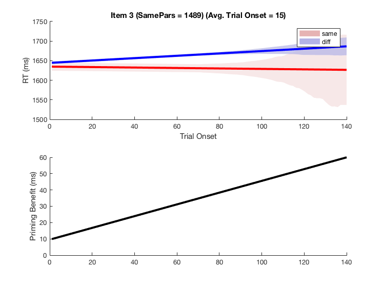

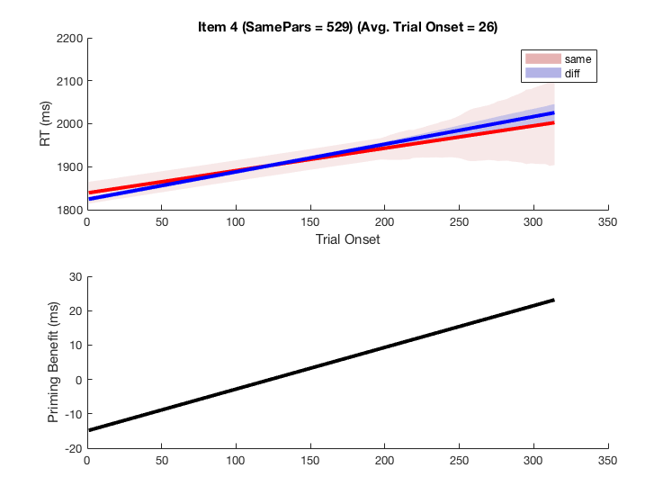

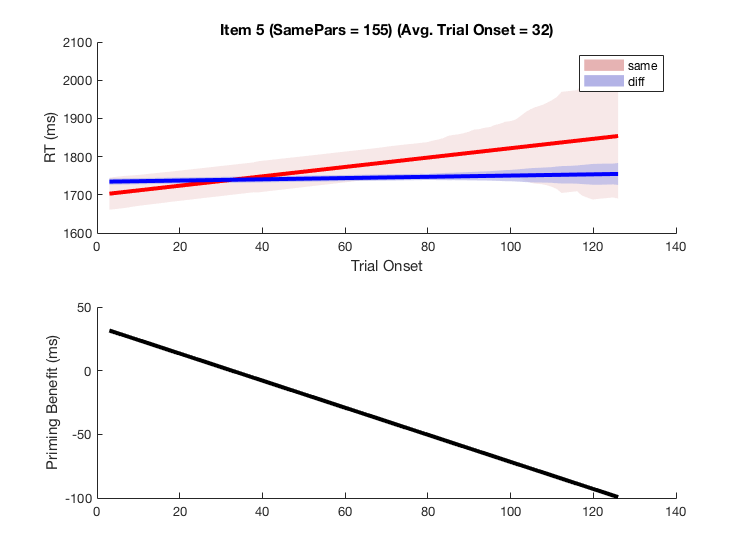

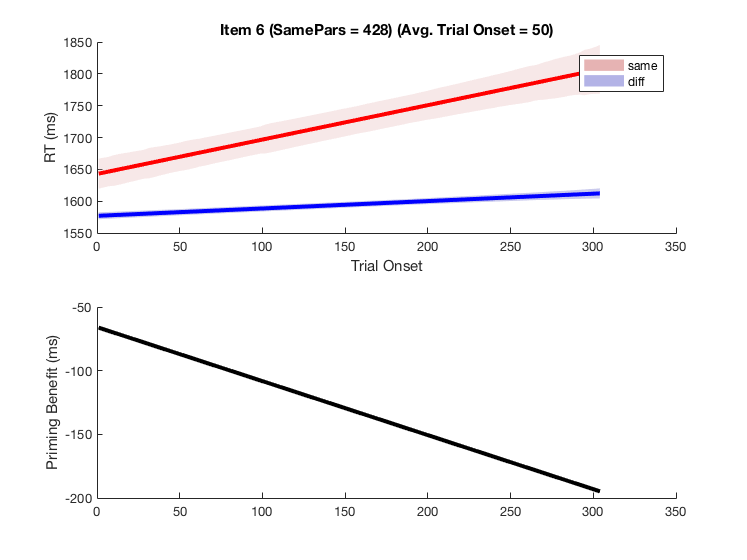

[3 more figures not shown]

```matlab
openfig('trial item 17.fig');
openfig('trial item 15.fig');
openfig('trial item 14.fig');
openfig('trial item 13.fig');
openfig('trial item 12.fig');
openfig('trial item 10.fig');
openfig('trial item 9.fig');
openfig('trial item 8.fig');
openfig('trial item 7.fig');
openfig('trial item 6.fig');
openfig('trial item 5.fig');
openfig('trial item 4.fig');
openfig('trial item 3.fig');
openfig('trial item 2.fig');
openfig('trial item 1.fig');
```

| **itemnum** | **slope_diff** | **avg. trial onset** |
| --- | --- | --- |
| 1 | -0.02 | 304 |
| 2 | -0.7 | 8 |
| 3 | 0.36 | 15 |
| 4 | 0.12 | 26 |
| 5 | -1.06 | 32 |
| 6 | -0.42 | 50 |
| 7 | -0.51 | 47 |
| 8 | 0.09 | 109 |
| 9 | -0.05 | 102 |
| 10 | 0.28 | 127 |
| 12 | -0.08 | 245 |
| 13 | -0.32 | 6 |
| 14 | -0.21 | 176 |
| 15 | 0.18 | 179 |
| 17 | -0.44 | 119 |

Here the median difference between slopes across all included targets was -0.0834, whereas for the previous analysis using exposure number the median difference between slopes was -0.7624.

Overall these plots convince me pretty well, but what statistical test am I supposed to do given all of this, and am I accounting for enough factors?